# 05 KSM predictive model

# Goal

Build a basic campaign prioritization model using all relevant variables extracted from the database and identified in previous work.

# Setup

```r
library(tidyverse)
library(reshape2)
library(gridExtra)
library(splines)
library(lubridate)
library(wranglR)
library(Boruta)
library(foreach)
library(doParallel)
library(glmnet)
library(glmnetUtils)
# Functions adapted from previous analysis steps
source('code/functions.R')
# Visualization functions adapted fron previous analysis steps
source('code/functions_viz.R')
# Set number of available CPU cores
registerDoParallel(detectCores() - 1)
```

# KSM model goals

The overarching goal is to predict giving over the final two years of the campaign. Ideally, I’d want to find expected future value, not just difference from expected value today. Consider the following:

$$E \left( \text{giving, donor | covariates} \right) = E \left(\text{giving | donor, covariates} \right) P \left(\text{donor | covariates} \right)$$

Estimate the expected future value as the product of an expected value and a probability. This can also be thought of as separate capacity and affinity models, and should give more useful estimates than $E\left( \text{giving | covariates} \right)$, which is left-censored by $0.

It’ll be informative seeing what features are more or less important at each stage of the two-step procedure, though I expect overall accuracy to suffer somewhat. Down the road it would be interesting to compare this to other methods, like trees and boosting.

# KSM model variables

The target variable is the sum of new gifts and commitments from 9/1/16 to 8/31/18 (FY17-18), given the state of the database on 8/31/16 (FY16).

As a general principle, point-in-time data is derived from entered date ranges where possible. Where dates are missing, it will be based upon the date added or date modified audit trail for each field, as suitable. The following data types received this treatment:

- All dollar amounts
- All giving behavior counts and years
- Student/alumni status
- All prospect assignments and ratings
- All contact information and indicators
- Employment
- Visits and outreach
- Engagement counts

This is implemented by [this SQL code](https://github.com/phively/ksm-models/blob/master/pg-cultivation-score-fy18/code/ksm-point-in-time-data-pull.sql).

```r
# Parameters
train_fy <- 2016
filepath <- 'data/2018-11-30 point-in-time data.xlsx'
sheetname <- 'Select point_in_time_model'

# Import data
source('code/generate-pit-data.R')

# Run data generation function
modeling.data <- generate_pit_data(filepath, sheetname)

# Create response variables
modeling.data <- modeling.data %>% mutate(
  rv.amt = NGC_TARGET_FY2 + NGC_TARGET_FY1
  , rv.gave = rv.amt > 0
) %>% select(
  # Drop future data
  -NGC_TARGET_FY2
  , -NGC_TARGET_FY1
  , -CASH_TARGET_FY2
  , -CASH_TARGET_FY1
  , -PLEDGE_TARGET_FY2
  , -PLEDGE_TARGET_FY1
  , -AF_TARGET_FY2
  , -AF_TARGET_FY1
  , -CRU_TARGET_FY2
  , -CRU_TARGET_FY1
) %>% filter(
  # Drop entities whose RECORD_YR is after the training year
  RECORD_YR <= train_fy
)
```

# Probability model

Logistic regression has been the workhorse of fundraising models for years. Some special considerations for this application:

- Minimizing predictive error, e.g. finding the model $\text{argmin}_m \sum_i \left[ y_i - \widehat{m}_x(x_i) \right]^2$, on in-sample data is the *wrong* metric!
- Focus on identifying as many current prospects as possible (minimizing type II error); type I is acceptable as these become new prospects.
- Avoid overfitting the training data. Techniques like cross-validation are highly recommended.
- Avoid endogenous variables; in this context, that means those that are causally associated with the outcome being measured, e.g. don’t use `Lifetime.Giving` as a predictor if the response variable is `Largest.Gift`.

I have [previously found](https://github.com/phively/ksm-models/tree/master/af-10k-fy17) that penalized logistic regression, such as implemented in R by the glmnet package, works better than standard logistic regression, so that’s the technique that I’ll use here.

Here, the response variable is:

$$Y_i = I \left( \text{FY18Giving}_i + \text{FY17Giving}_i > 0 \right)$$

## Variable selection

I like computing random forest variable importance, e.g. [Sauve & Tuleau-Malot (2014)](https://hal-unice.archives-ouvertes.fr/hal-00551375/document), to pre-screen variables. Define variable importance in a random forest as the change in MSE when permuting a given observation vector. One nice feature is that highly correlated variables should be similarly important.

```r
# Sample rows
prop = 1/5 # Proportion of data to sample
set.seed(287092)
samp <- sample_n(modeling.data, size = nrow(modeling.data) * prop)

# Run Boruta algorithm
rf.vars <- Boruta(
    y = as.numeric(samp$rv.gave)
    , x = samp %>% select(-rv.amt, -rv.gave)
    , seed = 5993207
  )
```

```r
rf.vars %>% print()
```

[output not shown]

Save the results.

```r
save(rf.vars, file = 'data/rf.vars.Rdata')
```

Plot the results.

```r
(pmod_plot <- rf.vars %>% Borutadata() %>% Borutaplotter())
```

[output not shown]

Basically, the algorithm creates dummy “shadow” variables, which are permuted versions of the explanatory variables appearing above, and random forests are fit on both the real and dummy variables. Intuitively, if replacing a variable with a randomly permuted version of itself does not reduce the random forest classifier’s accuracy, then the variable should not be included in a final model and can be discarded.

Recall that the response variable is making a new gift or commitment at any level within the next two years. From past experience, I know that most donations are outright gifts, under $1,000, and to an annual giving allocation. So the following is not too surprising:

- Past giving is the best predictor of future giving
- More recent giving behavior is more predictive than less recent giving behavior
- Other engagement indicators (e.g. events, committees) are predictive in aggregate
- Cash is more predictive than new gifts & commitments
- Having active home contact information is predictive

I found these more surprising:

- Having business contact information is not predictive
- Prospect indicators (is a prospect, number of visits, rating, etc.) are only weakly predictive
- ID numbers are predictive, but other personal identifiers like name are not – presumably because of the ID number/age correlation?
- KSM-specific engagement is more predictive than NU engagement

```r
(recommended.vars <- TentativeRoughFix(rf.vars))
```

[output not shown]

```r
# Check variable correlations
recommended_vars <- recommended.vars$finalDecision[
  which(recommended.vars$finalDecision == 'Confirmed')] %>% names()
numeric_vars <- modeling.data %>%
  select(recommended_vars) %>%
  select(-ID_NUMBER, -HOUSEHOLD_ID) %>%
  select_if(is.numeric)
numeric_vars %>% plot_corrs(textsize = 2)
```

[output not shown]

- AF, cash, and CRU are not as highly correlated as I would’ve expected. However, AF and CRU are moderately highly correlated, AF’s definition has changed over time, so consider using CRU and cash only.
- Count of gifts and payments, count of cash gifts, count of FYs supported, and count of allocations supported are all highly correlated. Consider dropping some of them.

## Cross-validation

Begin by creating the modeling data file.

```r
# Data file with variables removed
mdat <- modeling.data %>% select(rv.gave, recommended_vars) %>%
  select(
    -VELOCITY3_NGC, -VELOCITY_BINS_NGC, -VELOCITY_BINS_CASH, -VELOCITY3_LIN_NGC
    , -GIVING_MAX_PLEDGE_YR, -GIVING_MAX_PLEDGE_FY, -CRU_STATUS
    , -NGC_PFY1, -NGC_PFY2, -NGC_PFY3, -NGC_PFY4, -NGC_PFY5
    , -AF_PFY1, -AF_PFY2, -AF_PFY3, -AF_PFY4, -AF_PFY5
    , -GIVING_MAX_CASH_FY, -GIVING_NGC_TOTAL, -UPGRADE3_NGC, -LOYAL_5_PCT_ANY
    , -DEGREES_CONCAT, -BIRTH_DT, -FIRST_KSM_YEAR
    , -ID_NUMBER, -INSTITUTIONAL_SUFFIX # Keep HHID but don't use in modeling
    , -KSM_GOS, -HOUSEHOLD_COUNTRY
    , -KSM_EVENTS_ATTENDED, -EVENTS_ATTENDED
  ) %>% mutate(
    # Create spouse flag
    SPOUSE_ALUM = ifelse(SPOUSE_FIRST_KSM_YEAR > 0, 'TRUE', 'FALSE') %>% factor()
  ) %>% mutate_if(
    # Numeric variables over 1E4 get a log10 transformation
    function(x) {
      ifelse(is.numeric(x), max(x) >= 1E4, FALSE)
    }
    , log10plus1
  )

# Cross-validation settings
folds = 10
reps = 5

# Withhold 10% of data as test set
xv <- KFoldXVal(mdat, k = 2, prop = .1, seed = 4960582)
holdoutdat <- mdat[xv[[1]], ]
traindat <- mdat[xv[[2]], ]
remove(xv)
```

### Recommendations

- 10-fold cross-validation repeated 5 times
- Estimate prediction error with out-of-sample classification error
- $\theta_{1}$ threshold (donors) set to the empirical probability in the cross-validation set
- Try to preserve continuous variables; reasonable monotonic transformations are fine, but avoid discretization

### Penalized logistic regression

I’ll use a penalized ridge regression model as implemented by glmnet. Advantages of shrinkage techniques include automatically controlling for overfitting and collinearity.

```r
# Store timings
timestamps <- list()
# Store model errors
glm_nospline <- list()
# Seed for reproducibility
set.seed(2934223)

# Outer loop (repetitions)
for (rep in 1:reps) {
  # Status report
  timestamp <- paste('+ Iteration', rep, 'beginning at:', Sys.time())
  print(timestamp)
  timestamps <- c(timestamps, timestamp)
  # Create cross-validation indices
  xv <- KFoldXVal(traindat, k = folds)
  # Inner loop (parallel cross-validation)
  errs_out <- foreach(
    fold = 1:length(xv)
    , .combine = c
    , .packages = c('glmnet', 'glmnetUtils', 'dplyr', 'splines')
  ) %dopar% {
    # Fit temp model, where alpha = 0 is the ridge regression penalty
      tmpmodel <- cv.glmnet(
        rv.gave ~ .
        # Train while withholding some data
        , data = traindat[-xv[[fold]], ] %>% select(-HOUSEHOLD_ID)
        , family = 'binomial'
        , alpha = 0
        , lambda = 2^(-8:5)
      )
    # Prediction threshold
    theta1 <- sum(traindat$rv.gave[-xv[[fold]]] == 1) / nrow(traindat[-xv[[fold]], ])
    # Confusion matrix based on the withheld data
    tmpconfus <- conf_matrix_glmnet(tmpmodel, newdata = traindat[xv[[fold]], ], rv = 'rv.gave', threshold = theta1)
    # Return results
    return(
      list(
        conf_matrix = tmpconfus$conf_matrix
        , conf_matrix_pct = tmpconfus$conf_matrix_pct
        , errors = data.frame(
          reps = rep
          , folds = fold
          , error = tmpconfus$error
          , precision = tmpconfus$precision
          , sensitivity = tmpconfus$sensitivity
          , F1_score = tmpconfus$F1_score
        )
      )
    )
  }
  # Write results to errors data frame
  glm_nospline <- c(glm_nospline, errs_out)
  # Status report
  timestamp <- paste(' -Iteration', rep, 'ending at:   ', Sys.time())
  print(timestamp)
  timestamps <- c(timestamps, timestamp)
}
```

```r
glm_nospline_timestamps %>% unlist() %>% print()
```

```
 [1] "+ Iteration 1 beginning at: 2018-12-10 17:17:23"
 [2] " -Iteration 1 ending at:    2018-12-10 17:19:48"
 [3] "+ Iteration 2 beginning at: 2018-12-10 17:19:48"
 [4] " -Iteration 2 ending at:    2018-12-10 17:22:01"
 [5] "+ Iteration 3 beginning at: 2018-12-10 17:22:01"
 [6] " -Iteration 3 ending at:    2018-12-10 17:24:00"
 [7] "+ Iteration 4 beginning at: 2018-12-10 17:24:00"
 [8] " -Iteration 4 ending at:    2018-12-10 17:25:58"
 [9] "+ Iteration 5 beginning at: 2018-12-10 17:25:58"
[10] " -Iteration 5 ending at:    2018-12-10 17:27:53"
```

```r
# Function to reshape list data
combine_xval <- function(xval_results = list()) {
  # Function to reformat list output into groups
  delister <- function(full_list, first_idx = 1, seq) {
    output <- list()
    idx <- seq(first_idx, length(full_list), by = seq)
    for (i in 1:length(idx)) {
      output <- c(output, full_list[idx[i]])
    }
    return(output)
  }
  # Separate the output into groups of 3
  conf_matrix = delister(xval_results, 1, 3)
  conf_matrix_pct = delister(xval_results, 2, 3)
  errors = delister(xval_results, 3, 3)
  # Turn errors into a data frame
  errors <- foreach(i = 1:length(errors), .combine = rbind) %do% {
    return(errors[[i]])
  } %>% data.frame()
  # Return organized list
  return(
    list(
      conf_matrix = conf_matrix
      , conf_matrix_pct = conf_matrix_pct
      , errors = errors
    )
  )
}
```

```r
# Save results
glm_nospline_results <- combine_xval(glm_nospline)
glm_nospline_timestamps <- timestamps
save(glm_nospline_results, glm_nospline_timestamps, file = 'data/glm_nospline.Rdata')
```

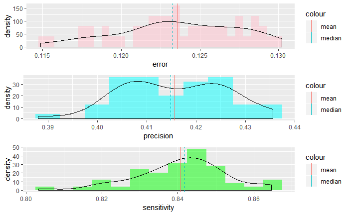

```r
grid.arrange(
    histogrammer(glm_nospline_results$errors, 'error', h = .0005, fill = 'pink')
  , histogrammer(glm_nospline_results$errors, 'precision', h = .005, fill = 'cyan')
  , histogrammer(glm_nospline_results$errors, 'sensitivity', h = .005, fill = 'green')
)
```

Let TP, TN, FP, FN refer to true positives, true negatives, false positives, and false negatives respectively.

$$\text{error} = \frac{FP + FN}{n}$$
$$\text{precision} = \frac{TP}{TP + FP}$$
$$\text{sensitivity} = \frac{TP}{TP + FN}$$

Compared to the AF $10K model, this has higher error due to the decreased sensitivity, but much higher precision.

The metrics to beat so far:

|  | glm_nospline_baseline |
| --- | --- |
| error | 0.1235965 |
| precision | 0.4155663 |
| sensitivity | 0.8406817 |
| F1_score | 0.2780529 |

### Standard logistic regression

Consider a standard logistic regression model to get a better sense of the explanatory variables.

```r
glm_standard <- glm(
  rv.gave ~ .
  , data = traindat %>% select(-HOUSEHOLD_ID) %>%
    select(-RECORD_STATUS_CODE) # Results in separation if included
  , family = 'binomial'
)
```

```r
summary(glm_standard)
```

```
Call:
glm(formula = rv.gave ~ ., family = "binomial", data = traindat %>%
    select(-HOUSEHOLD_ID) %>% select(-RECORD_STATUS_CODE))

Deviance Residuals:
    Min       1Q   Median       3Q      Max
-2.5698 -0.2622 -0.1272 -0.0243  3.6243

Coefficients:
                                   Estimate Std. Error z value Pr(>|z|)
(Intercept)                      -9.798e+01  1.999e+01  -4.900 9.57e-07 ***
PROGRAM_GROUPNONE                -1.206e+00  3.627e-01  -3.324 0.000887 ***
PROGRAM_GROUPEMP                 -4.329e-01  1.929e-01  -2.245 0.024789 *
PROGRAM_GROUPEXECED              -2.832e+00  9.097e-01  -3.113 0.001850 **
PROGRAM_GROUPNONGRD              -1.257e+01  2.815e+02  -0.045 0.964391
PROGRAM_GROUPPHD                 -1.890e+00  1.368e+00  -1.382 0.167061
PROGRAM_GROUPTMP                 -1.737e-01  1.602e-01  -1.084 0.278260
SPOUSE_FIRST_KSM_YEAR             4.710e-03  2.367e-02   0.199 0.842280
PREF_ADDR_TYPE_CODEALT           -1.648e-01  5.394e-01  -0.306 0.759927
PREF_ADDR_TYPE_CODEBUS           -3.586e-02  2.267e-01  -0.158 0.874304
HOUSEHOLD_CONTINENT              -2.809e+00  6.082e-01  -4.619 3.85e-06 ***
HOUSEHOLD_CONTINENTAfrica         9.811e-01  1.065e+00   0.921 0.357081
HOUSEHOLD_CONTINENTAsia           5.199e-02  2.452e-01   0.212 0.832105
HOUSEHOLD_CONTINENTEurope        -7.461e-01  3.957e-01  -1.885 0.059381 .
HOUSEHOLD_CONTINENTOceania       -2.049e+00  1.329e+00  -1.542 0.123086
HOUSEHOLD_CONTINENTSouth America -1.949e+00  1.046e+00  -1.864 0.062390 .
BUS_IS_EMPLOYEDTRUE               3.523e-01  1.882e-01   1.872 0.061231 .
HAS_HOME_ADDRTRUE                -2.556e-01  1.218e-01  -2.099 0.035809 *
HAS_HOME_PHONETRUE               -3.122e-01  1.275e-01  -2.449 0.014333 *
HAS_HOME_EMAILTRUE                8.856e-02  1.508e-01   0.587 0.557122
GIVING_FIRST_YEAR                -1.669e-02  1.181e-02  -1.413 0.157645
GIVING_FIRST_YEAR_CASH_AMT       -1.882e-01  8.411e-02  -2.237 0.025286 *
GIVING_FIRST_YEAR_PLEDGE_AMT     -5.385e-02  9.753e-02  -0.552 0.580864
GIVING_MAX_CASH_AMT               7.247e-02  2.975e-01   0.244 0.807528
GIVING_MAX_PLEDGE_AMT             9.012e-01  1.526e+00   0.591 0.554811
GIVING_CASH_TOTAL                 2.071e-01  4.065e-01   0.510 0.610398
GIVING_PLEDGE_TOTAL              -1.195e+00  1.587e+00  -0.753 0.451433
GIVING_AF_TOTAL                  -6.665e-02  9.750e-02  -0.684 0.494195
GIVING_CRU_TOTAL                  4.157e-01  2.734e-01   1.520 0.128386
GIFTS_ALLOCS_SUPPORTED            1.548e-01  6.779e-02   2.284 0.022366 *
```

[output cut: 80 more lines]

```
UPGRADE3_CASH1                   -3.543e-01  6.801e-01  -0.521 0.602450
UPGRADE3_CASH2                   -3.322e-01  7.657e-01  -0.434 0.664372
VELOCITY3_CASH                   -4.990e-01  4.077e-01  -1.224 0.221049
VELOCITY3_LIN_CASH                2.039e-01  1.009e-01   2.022 0.043220 *
SPOUSE_ALUMTRUE                  -9.020e+00  4.731e+01  -0.191 0.848797
---
Signif. codes:  0 ‘***’ 0.001 ‘**’ 0.01 ‘*’ 0.05 ‘.’ 0.1 ‘ ’ 1

(Dispersion parameter for binomial family taken to be 1)

    Null deviance: 5263.0  on 8455  degrees of freedom
Residual deviance: 2575.4  on 8341  degrees of freedom
AIC: 2805.4

Number of Fisher Scoring iterations: 16
```

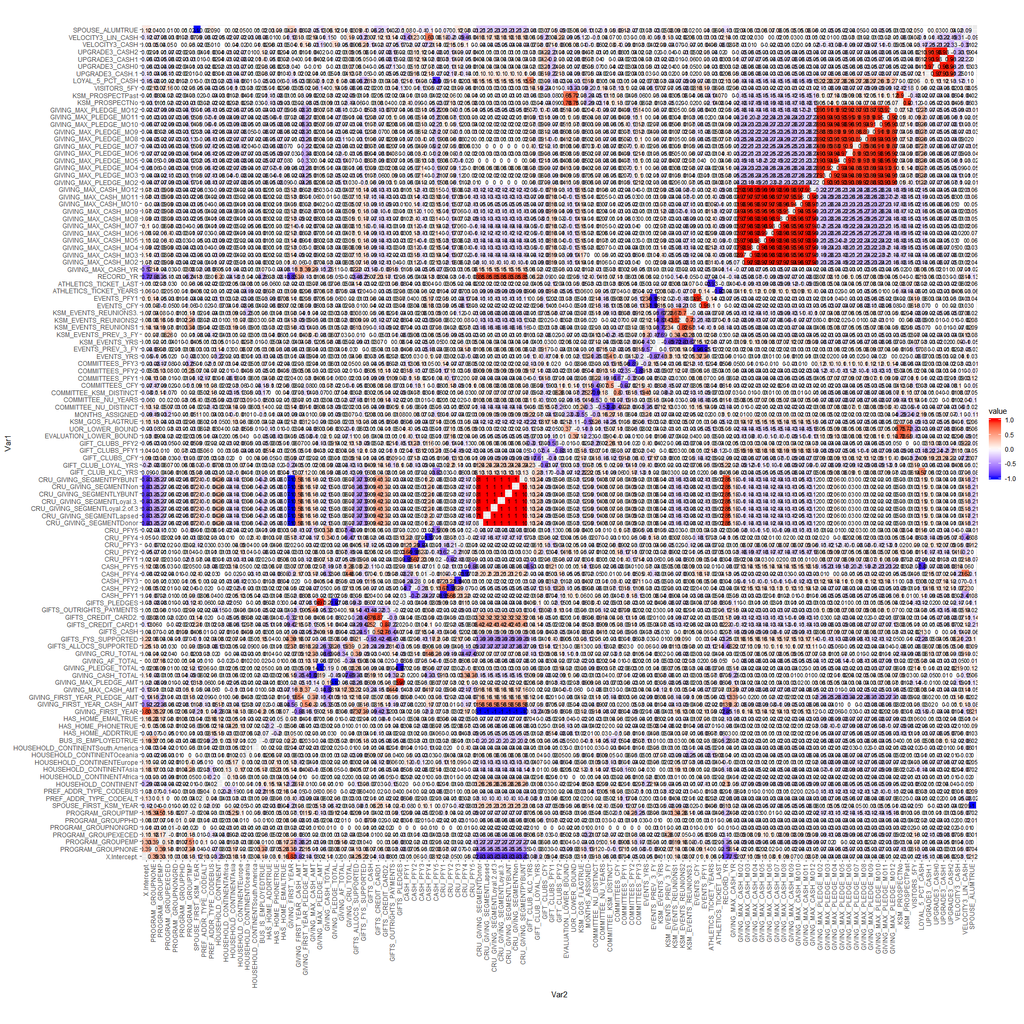

```r
summary(glm_standard, corr = TRUE)$correlation %>%
  data.frame() %>%
  plot_corrs()
```

Pretty eyewatering. Look at the term plots.

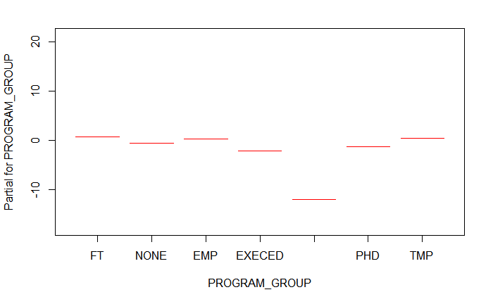

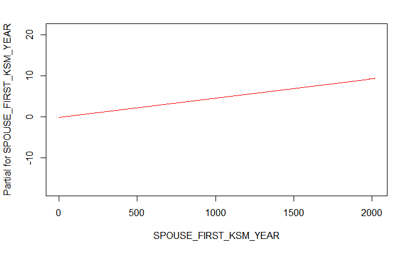

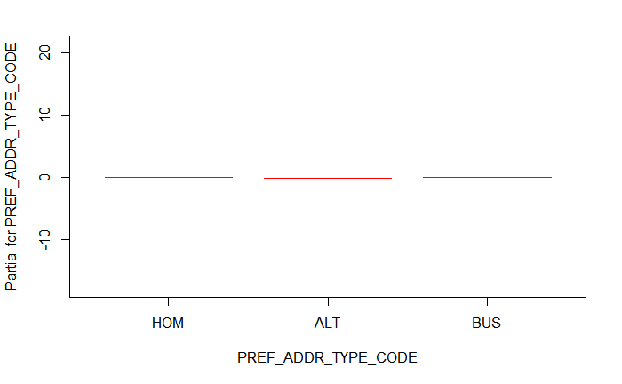

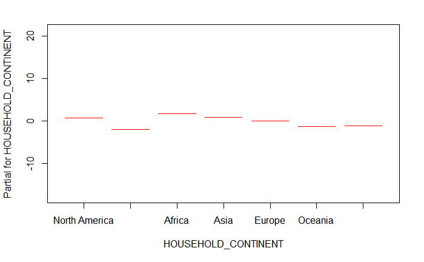

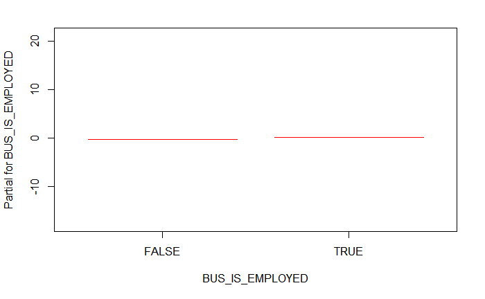

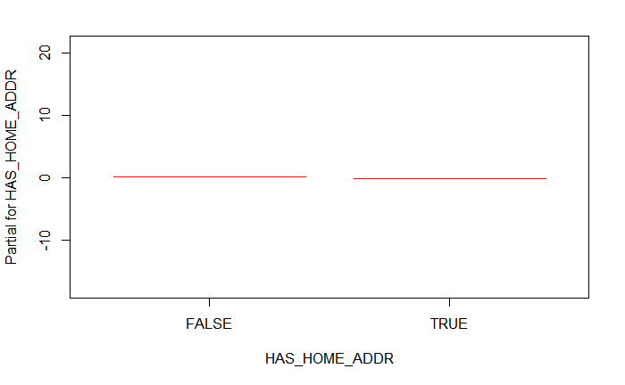

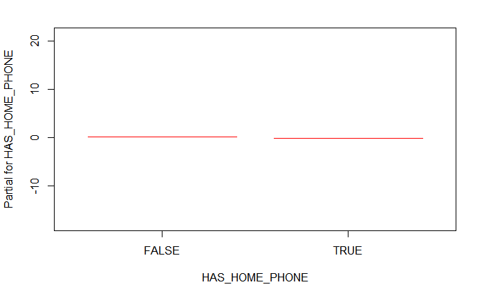

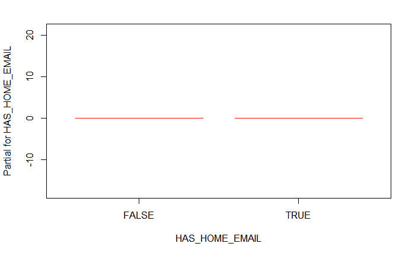

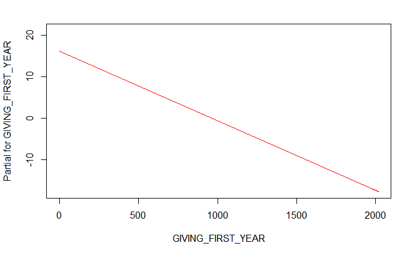

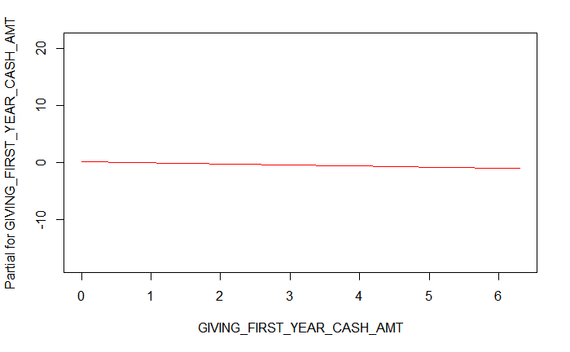

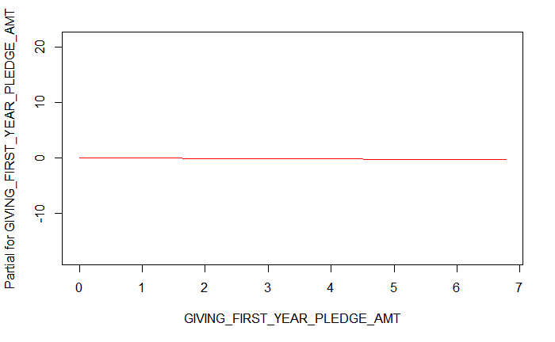

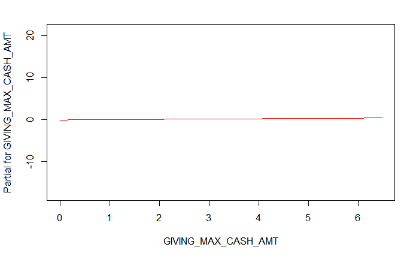

[58 more figures not shown]

```r
termplot(glm_standard)
```

Definitely keep:

- Program group looks very interesting
- CRU giving segment looks very interesting too
- Spouse alum or spouse KSM year, not both

Definitely drop:

- Pref addr type code
- Has Home Email
- Gifts credit card
- Gift clubs fields
- KSM GOs flag
- KSM Events Reunions
- Giving max pledge mo

Needs transformation:

- Giving first year
- Months assigned
- Events prev 3 FY
- Events CFY
- Athletics ticket last
- Record yr
- Max cash year

Duplicative:

- Giving first year pledge amt
- Giving max cash amt
- Giving AF total
- Gifts outrights payments
- CRU PFY1 through 5
- Committees CFY and PFY 1-3
- Events yrs and KSM events yrs
- Velocity3 cash
- Spouse first KSM year

```r
glm_standard <- glm_standard %>% update(
  data = traindat %>% select(
    -HOUSEHOLD_ID
    , -RECORD_STATUS_CODE
    # Drop
    , PREF_ADDR_TYPE_CODE
    , -HAS_HOME_EMAIL
    , -GIFTS_CREDIT_CARD
    , -contains('GIFT_CLUB')
    , -KSM_GOS_FLAG
    , -KSM_EVENTS_REUNIONS
    , -GIVING_MAX_PLEDGE_MO
    # Duplicative
    , -GIVING_FIRST_YEAR_PLEDGE_AMT
    , -GIVING_MAX_CASH_AMT
    , -GIVING_AF_TOTAL
    , -GIFTS_OUTRIGHTS_PAYMENTS
    , -contains('CRU_PFY')
    , -contains('COMMITTEES_')
    , -contains('EVENTS_YRS')
    , -VELOCITY3_CASH
    , -SPOUSE_FIRST_KSM_YEAR
  )
)
```

```r
summary(glm_standard)
```

```
Call:
glm(formula = rv.gave ~ ., family = "binomial", data = traindat %>%
    select(-HOUSEHOLD_ID, -RECORD_STATUS_CODE, PREF_ADDR_TYPE_CODE,
        -HAS_HOME_EMAIL, -GIFTS_CREDIT_CARD, -contains("GIFT_CLUB"),
        -KSM_GOS_FLAG, -KSM_EVENTS_REUNIONS, -GIVING_MAX_PLEDGE_MO,
        -GIVING_FIRST_YEAR_PLEDGE_AMT, -GIVING_MAX_CASH_AMT,
        -GIVING_AF_TOTAL, -GIFTS_OUTRIGHTS_PAYMENTS, -contains("CRU_PFY"),
        -contains("COMMITTEES_"), -contains("EVENTS_YRS"), -VELOCITY3_CASH,
        -SPOUSE_FIRST_KSM_YEAR))

Deviance Residuals:
    Min       1Q   Median       3Q      Max
-2.5370  -0.2692  -0.1294  -0.0245   3.7065

Coefficients:
                                   Estimate Std. Error z value Pr(>|z|)
(Intercept)                      -1.017e+02  1.923e+01  -5.287 1.24e-07 ***
PROGRAM_GROUPNONE                -1.162e+00  3.373e-01  -3.447 0.000568 ***
PROGRAM_GROUPEMP                 -4.934e-01  1.825e-01  -2.703 0.006862 **
PROGRAM_GROUPEXECED              -2.963e+00  9.079e-01  -3.263 0.001102 **
PROGRAM_GROUPNONGRD              -1.266e+01  2.816e+02  -0.045 0.964143
PROGRAM_GROUPPHD                 -2.012e+00  1.419e+00  -1.418 0.156239
PROGRAM_GROUPTMP                 -2.223e-01  1.486e-01  -1.496 0.134743
PREF_ADDR_TYPE_CODEALT           -2.486e-01  5.404e-01  -0.460 0.645539
PREF_ADDR_TYPE_CODEBUS           -7.062e-02  2.234e-01  -0.316 0.751967
HOUSEHOLD_CONTINENT              -2.890e+00  5.923e-01  -4.880 1.06e-06 ***
HOUSEHOLD_CONTINENTAfrica         8.810e-01  1.063e+00   0.829 0.407218
HOUSEHOLD_CONTINENTAsia          -6.824e-05  2.399e-01   0.000 0.999773
HOUSEHOLD_CONTINENTEurope        -7.322e-01  3.895e-01  -1.880 0.060149 .
HOUSEHOLD_CONTINENTOceania       -2.061e+00  1.305e+00  -1.579 0.114238
HOUSEHOLD_CONTINENTSouth America -1.925e+00  1.042e+00  -1.848 0.064664 .
BUS_IS_EMPLOYEDTRUE               3.378e-01  1.837e-01   1.839 0.065924 .
HAS_HOME_ADDRTRUE                -2.619e-01  1.193e-01  -2.195 0.028186 *
HAS_HOME_PHONETRUE               -3.149e-01  1.251e-01  -2.518 0.011816 *
GIVING_FIRST_YEAR                -1.234e-02  1.120e-02  -1.102 0.270426
GIVING_FIRST_YEAR_CASH_AMT       -1.908e-01  7.208e-02  -2.647 0.008117 **
GIVING_MAX_PLEDGE_AMT             1.043e+00  1.465e+00   0.712 0.476325
GIVING_CASH_TOTAL                 5.653e-01  2.276e-01   2.484 0.012993 *
GIVING_PLEDGE_TOTAL              -1.367e+00  1.525e+00  -0.896 0.370042
GIVING_CRU_TOTAL                 -7.557e-02  2.131e-01  -0.355 0.722892
```

[output cut: 46 more lines]

```
UPGRADE3_CASH0                   -1.311e-01  5.664e-01  -0.231 0.816964
UPGRADE3_CASH1                   -6.675e-01  6.616e-01  -1.009 0.313008
UPGRADE3_CASH2                   -8.606e-01  7.197e-01  -1.196 0.231751
VELOCITY3_LIN_CASH                1.538e-01  9.372e-02   1.641 0.100738
SPOUSE_ALUMTRUE                   3.724e-01  2.599e-01   1.433 0.151775
---
Signif. codes:  0 ‘***’ 0.001 ‘**’ 0.01 ‘*’ 0.05 ‘.’ 0.1 ‘ ’ 1

(Dispersion parameter for binomial family taken to be 1)

    Null deviance: 5263.0  on 8455  degrees of freedom
Residual deviance: 2605.3  on 8381  degrees of freedom
AIC: 2755.3

Number of Fisher Scoring iterations: 16
```

Nice drop in the AIC.